# Regresión Logística Binomial

Alberto Almuiña

Septiembre 2019

# 1 Teoría

En este paquete diseñado para R, se ha implementado una regresión logística para clasificar una variable con dos clases (por ejemplo: 0/No-1/Sí). Para ello, se utiliza la función sigmoide, que viene definida por la siguiente ecuación:
$$h(z) = \frac{1}{1+\exp{(-z)}}$$

donde:
$$z = \theta^{T}\cdot x$$

La salida de esta función siempre estará contenida entre 0 y 1, como podemos observar en la siguiente imagen:

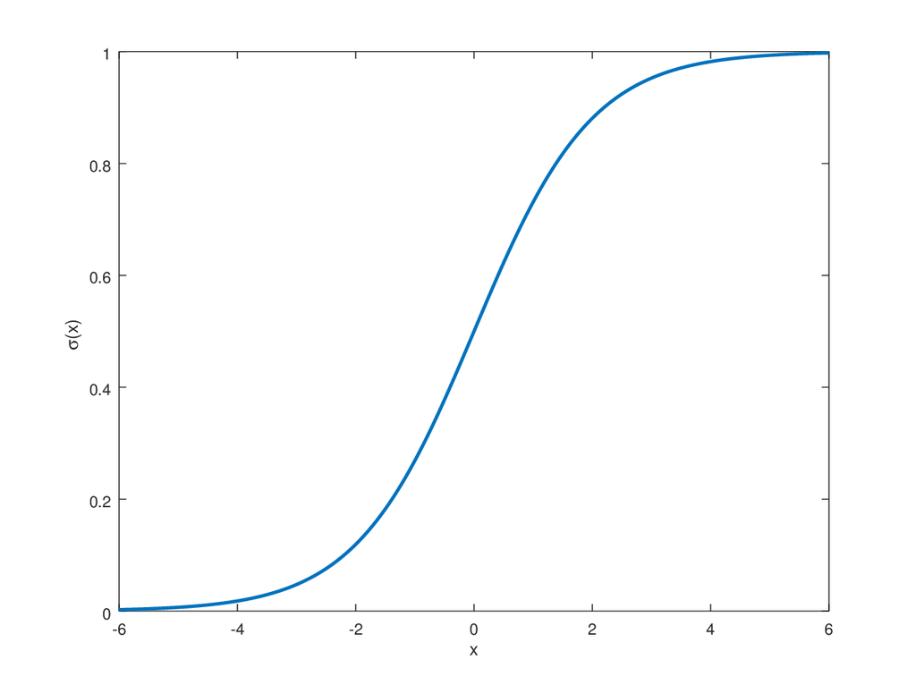

Función Sigmoide

En la función sigmoide, $\theta$ representa los pesos asignados. Definimos una función de coste que se minimizará para obtener los valores óptimos de los pesos, $J(\theta)$:
$$J(\theta) = -\frac{1}{m}\sum_{i=1}^{m}{[y_{i}\cdot log(h(z_{i})) + (1-y_{i}) \cdot log(1-h(z_{i}))]}$$

Utilizando el algoritmo de descenso del gradiente, y a través de la derivada parcial, obtenemos los valores óptimos:
$$\frac{\partial{J(\theta)}}{\partial{\theta_{j}}} = \frac{1}{m} \sum_{i=1}^{m}{[h(z^{i})-y^{i}] \cdot x_{j}^{i}}$$

Los pesos se van actualizando a partir de la siguiente ecuación:
$$\theta_{i} = \theta_{i-1} - \alpha \frac{\partial{J(\theta_{i-1})}}{\partial{\theta_{i-1}}}$$

donde:

- $\alpha$ = ratio de aprendizaje

En nuestro paquete, el algoritmo de descenso del gradiente se frenará en base a dos parámetros: el número máximo de iteraciones (max_iter) o cuando se alcance un valor umbral (threshold):

1. El algoritmo se parará cuando se alcance el número máximo de iteraciones.
2. Si se define un valor umbral, el algoritmo se frenará cuando $h(z) < umbral$, independientemente del número de la iteración.

# 2 Función

La función **logistic_regression** creada sigue la siguiente lógica:

1. Llama a la función **logistic_reg_comprobations** donde se comprueba que los parámetros de la llamada a la función sean correctos.
2. Llama a la función **prepare_logistic_reg_data** en el que se hace una multiasignación para dividir los datos de entrada en x_train, y_train, x_test y theta.
3. Llama a la función **gradient_descent** para obtener los valores óptimos de theta (los cuales minimizan la función de coste). También se calcula el valor de la función de coste para cada iteración.
4. Llama a la función **predict** en la que se predicen los valores tanto para la variable target del dataset de entrenamiento como el de test.
5. Análisis de los resultados (matriz de confusión, gráfico de dicha matriz, etc…)

# 3 Argumentos

Los argumentos de la función **logistic_regression** son los siguientes:

```
## function (train, test, target, lr = 0.001, max_iter = 1e+05,
##     probs = F, threshold = NULL, regu_factor = NULL, regu_method = "ridge",
##     epsilon = 1e-05, ...)
## NULL
```

donde:

- train: Dataset de entrenamiento
- test: Dataset de test
- target: variable que se ha de predecir (valor numérico)
- lr: Learning Rate para el algoritmo del descenso del gradiente
- max_iter: Número máximo de iteraciones en el algoritmo del descenso del gradiente
- probs: F si los resultados son categóricos, T si los resultados se dan como probabilidades (entre 0 y 1)
- regu_method: “ridge”, regularización de Ridge
- regu_factor: Factor de regularización para el método Ridge. Si no se cubre, no se usa regularización.

# 4 Ejemplo Dataset Adultos

## 4.1 Análisis de variables categóricas

```r
library(purrr) #Para programación funcional
library(dplyr) #Para manejar data.frames
library(stringr) #Para trabajar con cadenas de caracteres
library(data.table) #Para cargar rápido la información (fread es mucho más rápido que read.csv)
library(ggplot2) #Para visualizar
library(tidyr)
library(recipes) #Preprocesamiento de datos
library(VIM) #Visualización de Missing Values
library(devtools) #Importar librería propia (regresión logística)
library(zeallot) #Para asignación múltiple
library(corrplot) #Gráfico de correlaciones
library(prettydoc) #Temas de RMarkdown
library(factoextra) #Visualización PCA

# Cargamos el juego de datos
datosAdult <- fread('http://archive.ics.uci.edu/ml/machine-learning-databases/adult/adult.data',
                    stringsAsFactors = FALSE,
                    data.table = F,
                    header = FALSE)

# Nombres de los atributos
names(datosAdult) <- c("age","workclass","fnlwgt","education","education_num","marital_status","occupation","relationship","race","sex","capital_gain","capital_loss","hour_per_week","native_country","income")
```

En primer lugar, vemos la estructura de los datos cargados (para ver la clase del objeto, los nombres de las variables con sus correspondientes tipos, así como algunos valores de las mismas):

```r
str(datosAdult)
```

```
## 'data.frame':    32561 obs. of  15 variables:
##  $ age           : int  39 50 38 53 28 37 49 52 31 42 ...
##  $ workclass     : chr  "State-gov" "Self-emp-not-inc" "Private" "Private" ...
##  $ fnlwgt        : int  77516 83311 215646 234721 338409 284582 160187 209642 45781 159449 ...
##  $ education     : chr  "Bachelors" "Bachelors" "HS-grad" "11th" ...
##  $ education_num : int  13 13 9 7 13 14 5 9 14 13 ...
##  $ marital_status: chr  "Never-married" "Married-civ-spouse" "Divorced" "Married-civ-spouse" ...
##  $ occupation    : chr  "Adm-clerical" "Exec-managerial" "Handlers-cleaners" "Handlers-cleaners" ...
##  $ relationship  : chr  "Not-in-family" "Husband" "Not-in-family" "Husband" ...
##  $ race          : chr  "White" "White" "White" "Black" ...
##  $ sex           : chr  "Male" "Male" "Male" "Male" ...
##  $ capital_gain  : int  2174 0 0 0 0 0 0 0 14084 5178 ...
##  $ capital_loss  : int  0 0 0 0 0 0 0 0 0 0 ...
##  $ hour_per_week : int  40 13 40 40 40 40 16 45 50 40 ...
##  $ native_country: chr  "United-States" "United-States" "United-States" "United-States" ...
##  $ income        : chr  "<=50K" "<=50K" "<=50K" "<=50K" ...
```

Veamos a continuación un pequeño resumen de los datos:

```r
summary(datosAdult)
```

```
##       age         workclass             fnlwgt         education
##  Min.   :17.00   Length:32561       Min.   :  12285   Length:32561
##  1st Qu.:28.00   Class :character   1st Qu.: 117827   Class :character
##  Median :37.00   Mode  :character   Median : 178356   Mode  :character
##  Mean   :38.58                      Mean   : 189778
##  3rd Qu.:48.00                      3rd Qu.: 237051
##  Max.   :90.00                      Max.   :1484705
##  education_num   marital_status      occupation        relationship
##  Min.   : 1.00   Length:32561       Length:32561       Length:32561
##  1st Qu.: 9.00   Class :character   Class :character   Class :character
##  Median :10.00   Mode  :character   Mode  :character   Mode  :character
##  Mean   :10.08
##  3rd Qu.:12.00
##  Max.   :16.00
##      race               sex             capital_gain    capital_loss
##  Length:32561       Length:32561       Min.   :    0   Min.   :   0.0
##  Class :character   Class :character   1st Qu.:    0   1st Qu.:   0.0
##  Mode  :character   Mode  :character   Median :    0   Median :   0.0
##                                        Mean   : 1078   Mean   :  87.3
##                                        3rd Qu.:    0   3rd Qu.:   0.0
##                                        Max.   :99999   Max.   :4356.0
##  hour_per_week   native_country        income
##  Min.   : 1.00   Length:32561       Length:32561
##  1st Qu.:40.00   Class :character   Class :character
##  Median :40.00   Mode  :character   Mode  :character
##  Mean   :40.44
##  3rd Qu.:45.00
##  Max.   :99.00
```

Lo primero que podemos observar es que las variables numéricas se encuentran en un rango muy distinto de valores, por lo que podría ser una buena opción normalizarlas y reescalarlas (esto es muy importante sobre todo en determinados algoritmos en los que se necesita reescalar las variables numéricas obligatoriamente). También podemos observar que no hay ningún NA, puesto que de haberlo aparecería con esta función. También observamos que todas las variables no numéricas son de tipo character, por lo que vamos a transformarlas momentáneamente a factores para poder ver sus distintos niveles (esto nos permitirá comprobar los valores así como ver cuáles podrían ser discretizadas):

```r
datosAdult %>% select_if(., is.character) %>% map(., compose(levels, as.factor))
```

```
## $workclass
## [1] "?"                "Federal-gov"      "Local-gov"
## [4] "Never-worked"     "Private"          "Self-emp-inc"
## [7] "Self-emp-not-inc" "State-gov"        "Without-pay"
##
## $education
##  [1] "10th"         "11th"         "12th"         "1st-4th"
##  [5] "5th-6th"      "7th-8th"      "9th"          "Assoc-acdm"
##  [9] "Assoc-voc"    "Bachelors"    "Doctorate"    "HS-grad"
## [13] "Masters"      "Preschool"    "Prof-school"  "Some-college"
##
## $marital_status
## [1] "Divorced"              "Married-AF-spouse"     "Married-civ-spouse"
## [4] "Married-spouse-absent" "Never-married"         "Separated"
## [7] "Widowed"
```

[output cut: 44 more lines]

Esto nos permite obtener ya nuestras primeras conclusiones. Parece que el valor “?” actúa en este dataset como NA, por lo que habrá que analizar sus implicaciones posteriormente. Por otro lado, en base a los datos, **parece claro que el objetivo de este problema será predecir si una persona va a tener unos ingresos superiores a 50k o no**. Sobre las variables ‘sex’ e ‘income’ se aplicará el proceso one-hot encoding, que consiste en transformar variables categóricas en numéricas, haciendo más ancho el data.frame (por cada nivel de la variable se creará una columna). En este caso, como las variables sólo tienen una columna, podemos almacenar toda la información en una sóla columna (en un one-hot encoding, las columnas necesarias serán n-1 siendo n el número de niveles). Por otro lado, también es necesario comentar que sobre estas variables podría realizarse una discretización de las mismas, pero no se ha hecho por los siguientes motivos: hay muchos algoritmos que aceptan valores numéricos pero no factores (por ejemplo, las redes neuronales) y por otro lado, trabajar con valores numéricos siempre es más eficiente que con otro tipo de datos.

```r
datosAdult <- datosAdult %>% mutate(sex = if_else(sex == 'Male', 1, 0),
                                    income = if_else(income == '>50K', 1, 0))

str(datosAdult)
```

```
## 'data.frame':    32561 obs. of  15 variables:
##  $ age           : int  39 50 38 53 28 37 49 52 31 42 ...
##  $ workclass     : chr  "State-gov" "Self-emp-not-inc" "Private" "Private" ...
##  $ fnlwgt        : int  77516 83311 215646 234721 338409 284582 160187 209642 45781 159449 ...
##  $ education     : chr  "Bachelors" "Bachelors" "HS-grad" "11th" ...
##  $ education_num : int  13 13 9 7 13 14 5 9 14 13 ...
##  $ marital_status: chr  "Never-married" "Married-civ-spouse" "Divorced" "Married-civ-spouse" ...
##  $ occupation    : chr  "Adm-clerical" "Exec-managerial" "Handlers-cleaners" "Handlers-cleaners" ...
##  $ relationship  : chr  "Not-in-family" "Husband" "Not-in-family" "Husband" ...
##  $ race          : chr  "White" "White" "White" "Black" ...
##  $ sex           : num  1 1 1 1 0 0 0 1 0 1 ...
##  $ capital_gain  : int  2174 0 0 0 0 0 0 0 14084 5178 ...
##  $ capital_loss  : int  0 0 0 0 0 0 0 0 0 0 ...
##  $ hour_per_week : int  40 13 40 40 40 40 16 45 50 40 ...
##  $ native_country: chr  "United-States" "United-States" "United-States" "United-States" ...
##  $ income        : num  0 0 0 0 0 0 0 1 1 1 ...
```

```r
head(datosAdult[,c(10,15)]) %>% knitr::kable()
```

| sex | income |
| --- | --- |
| 1 | 0 |
| 1 | 0 |
| 1 | 0 |
| 1 | 0 |
| 0 | 0 |
| 0 | 0 |

También se puede observar que parece que hay información que está repetida. Por ejemplo, las variables ‘education’ y ‘education_num’ representan lo mismo, es decir, cada nivel de educacion tiene asignado un número. También parece haber cierta duplicación de información entre las variables ‘marital-status’ y ‘relationship’. Por ejemplo, los tres niveles de ‘Married..’ podrían ser mapeados con los niveles ‘Husband’ y ‘Wife’ de la otra variable, al igual que sucede con ‘Unmarried’ y ‘Never married’. Es posible que estas dos variables estén muy relacionadas entre sí. Por otro lado, podría ser beneficioso agrupar en nuevas categorías tanto la variable educativa (por ejemplo en algo como sin estudios, estudios básicos, medios y altos) al igual que agrupar las tres categorías ‘married..’ en una sola. En cualquier caso, antes de aventurarnos a tomar alguna decisión, vamos a graficar algunas variables para entender mejor nuestro dataset.

### 4.1.1 Income vs Nivel Educativo y Sexo

En primer lugar, vamos a analizar como son los ingresos en función del nivel educativo y del sexo:

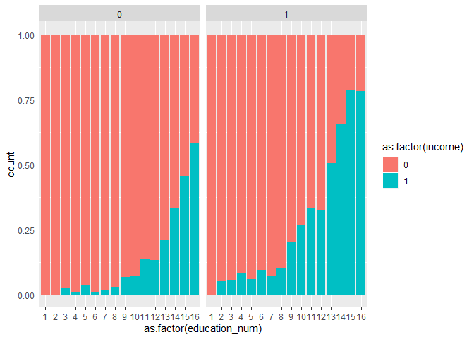

```r
ggplot(data = datosAdult,
       aes(x = as.factor(education_num), fill = as.factor(income))) +

  geom_bar(position = "fill") + facet_wrap(~sex)
```

```r
paste(ifelse(str_count(datosAdult$education_num) == 1,
             paste('0', as.character(datosAdult$education_num), sep = ""),
             datosAdult$education_num),
         datosAdult$education, sep = ": ") %>% unique() %>% sort() %>% as.matrix()
```

```
##       [,1]
##  [1,] "01: Preschool"
##  [2,] "02: 1st-4th"
##  [3,] "03: 5th-6th"
##  [4,] "04: 7th-8th"
##  [5,] "05: 9th"
##  [6,] "06: 10th"
##  [7,] "07: 11th"
##  [8,] "08: 12th"
##  [9,] "09: HS-grad"
## [10,] "10: Some-college"
## [11,] "11: Assoc-voc"
## [12,] "12: Assoc-acdm"
## [13,] "13: Bachelors"
## [14,] "14: Masters"
## [15,] "15: Prof-school"
## [16,] "16: Doctorate"
```

Podemos observar cómo para ambos sexos, cuánto mayor sea el nivel de educación mayor será el número de gente que gana más de 50k. También se puede ver cómo hay más hombres que mujeres que ganan esta cantidad (la diferencia entre ambos sexos es muy grande). Podemos redifinir en base a este gráfico la discretización de la variable education:

```r
datosAdult <- datosAdult %>% mutate(education = case_when(education_num %in% seq(1:8) ~ 'Básicos',
                                                          education %in% c('HS-grad', 'Some-college', 'Assoc-voc', 'Assoc-acdm',                                                                                'Bachelors') ~ 'Medios',
                                                          TRUE ~ 'Avanzados'))

datosAdult <- datosAdult %>% mutate(education = factor(education, levels = c('Básicos', 'Medios', 'Avanzados')))

table(datosAdult$education) %>% knitr::kable(col.names = c('Nivel de Estudios', 'Nº Observaciones'))
```

| Nivel de Estudios | Nº Observaciones |
| --- | --- |
| Básicos | 4253 |
| Medios | 25596 |
| Avanzados | 2712 |

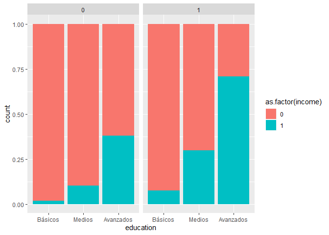

```r
ggplot(data = datosAdult,
       aes(x = education, fill = as.factor(income))) +

  geom_bar(position = "fill") + facet_wrap(~sex)
```

Es importante resaltar que una vez hecha la reducción de niveles de la variable education, la distribución de los valores es muy similar a la inicial (siempre que se hacen este tipo de transformaciones es necesario comprobar que se mantiene la naturaleza de los datos).

### 4.1.2 Income vs Sector Empleo y Profesión

A continuación representamos la distribución del sector del empleo y la profesión por los ingresos:

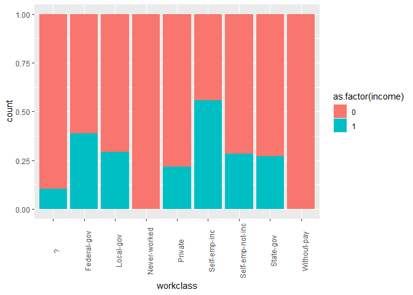

```r
ggplot(data = datosAdult,
       aes(x = workclass, fill = as.factor(income))) +
  geom_bar(position = "fill") +
  theme(axis.text.x = element_text(angle = 90))
```

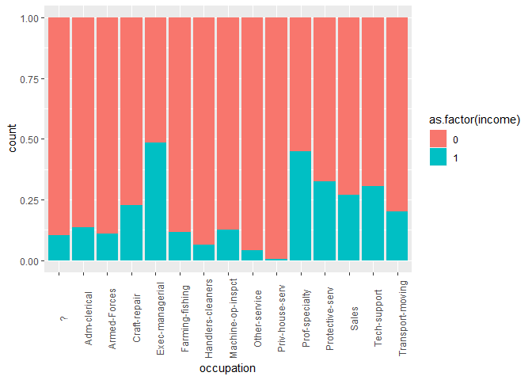

```r
ggplot(data = datosAdult,
       aes(x = occupation, fill = as.factor(income))) +
  geom_bar(position = "fill") +
  theme(axis.text.x = element_text(angle = 90))
```

```r
table(datosAdult$workclass) %>% knitr::kable(col.names = c('Tipo Trabajo', 'Nº Observaciones'))
```

| Tipo Trabajo | Nº Observaciones |
| --- | --- |
| ? | 1836 |
| Federal-gov | 960 |
| Local-gov | 2093 |
| Never-worked | 7 |
| Private | 22696 |
| Self-emp-inc | 1116 |
| Self-emp-not-inc | 2541 |
| State-gov | 1298 |
| Without-pay | 14 |

```r
table(datosAdult$occupation) %>% knitr::kable(col.names = c('Profesión', 'Nº Observaciones'))
```

| Profesión | Nº Observaciones |
| --- | --- |
| ? | 1843 |
| Adm-clerical | 3770 |
| Armed-Forces | 9 |
| Craft-repair | 4099 |
| Exec-managerial | 4066 |
| Farming-fishing | 994 |
| Handlers-cleaners | 1370 |
| Machine-op-inspct | 2002 |
| Other-service | 3295 |
| Priv-house-serv | 149 |
| Prof-specialty | 4140 |
| Protective-serv | 649 |
| Sales | 3650 |
| Tech-support | 928 |
| Transport-moving | 1597 |

```r
datosAdult %>% select(workclass, occupation) %>% filter(workclass == "?" & occupation == "?") %>% count()
```

```
## # A tibble: 1 x 1
##       n
##   <int>
## 1  1836
```

### 4.1.3 Income vs Edad

Mostramos a continuación una gráfica de cómo afecta la edad a los ingresos:

```r
datosAdult <- datosAdult %>% mutate(age_breaks = cut(age, breaks = c(0, 30, 55, 100), labels = c('Joven', 'Adulto', 'Anciano')))

table(datosAdult$age_breaks) %>% knitr::kable(col.names = c('Edad Sectorizada', 'Nº Observaciones'))
```

| Edad Sectorizada | Nº Observaciones |
| --- | --- |
| Joven | 10572 |
| Adulto | 17900 |
| Anciano | 4089 |

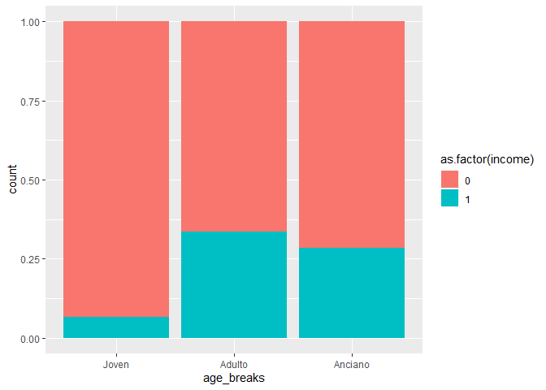

```r
ggplot(data = datosAdult,
       aes(x = age_breaks, fill = as.factor(income))) +

  geom_bar(position = "fill")
```

### 4.1.4 Income vs Marital_Status y Relationship

Vamos a analizar ahora la relación de la variable objetivo con las variables relationship y marital_status, puesto que entendemos que están muy relacionadas como mencionamos anteriormente. Hemos juntado los tres niveles que comenzaban por ‘Married’ en uno sólo denominado así, ‘Married’. Los resultados son bastante sorprendentes, puesto que la gente casada tiene una mayor tendencia según este dataset a obtener unos ingresos más elevados (por encima de 50k), cómo se puede ver a partir de ambas variables categóricas (realmente, ambas nos están dando prácticamente la misma información):

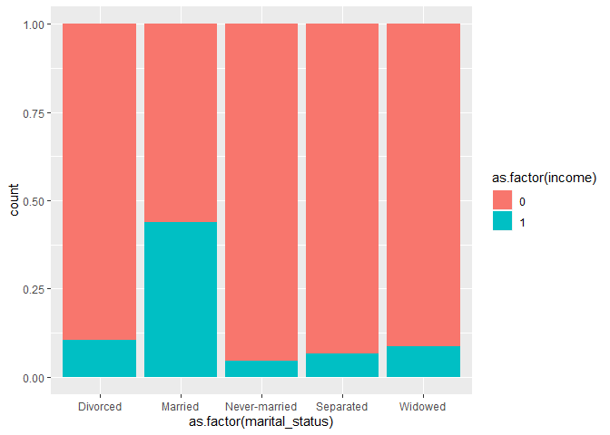

```r
datosAdult <- datosAdult %>% mutate(marital_status = str_replace_all(marital_status,
                                                                     pattern='Married-AF-spouse|Married-civ-spouse|Married-spouse-absent',
                                                                     replacement = 'Married'))

ggplot(data = datosAdult,
       aes(x = as.factor(marital_status), fill = as.factor(income))) +

  geom_bar(position = "fill")
```

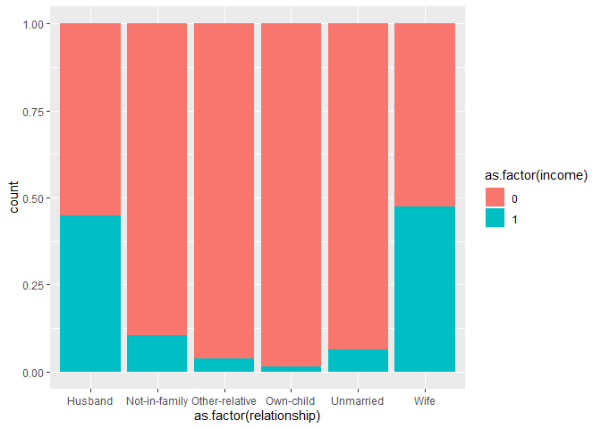

```r
ggplot(data = datosAdult,
       aes(x = as.factor(relationship), fill = as.factor(income))) +

  geom_bar(position = "fill")
```

```r
table(datosAdult$marital_status) %>% knitr::kable(col.names = c('Estado Marital', 'Nº Observaciones'))
```

| Estado Marital | Nº Observaciones |
| --- | --- |
| Divorced | 4443 |
| Married | 15417 |
| Never-married | 10683 |
| Separated | 1025 |
| Widowed | 993 |

```r
table(datosAdult$relationship) %>% knitr::kable(col.names = c('Relación', 'Nº Observaciones'))
```

| Relación | Nº Observaciones |
| --- | --- |
| Husband | 13193 |
| Not-in-family | 8305 |
| Other-relative | 981 |
| Own-child | 5068 |
| Unmarried | 3446 |
| Wife | 1568 |

### 4.1.5 Income vs Raza

Analicemos ahora los ingresos por raza:

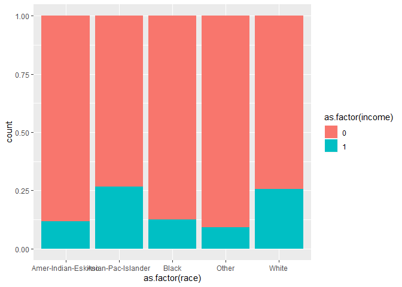

```r
ggplot(data = datosAdult,
       aes(x = as.factor(race), fill = as.factor(income))) +
  geom_bar(position = "fill")
```

```r
 table(datosAdult$race) %>% knitr::kable(col.names = c('Raza', 'Nº Observaciones'))
```

| Raza | Nº Observaciones |
| --- | --- |
| Amer-Indian-Eskimo | 311 |
| Asian-Pac-Islander | 1039 |
| Black | 3124 |
| Other | 271 |
| White | 27816 |

### 4.1.6 Income vs País

Respecto al país sucede algo similar, el 90% de los datos están concentrados en Estados Unidos y el restante 10% está demasiado distribuido entre varios países, por lo que no tendría demasiado sentido hacer un análisis por países debido a la poca cantidad de información en paises restantes (Por lo tanto, tampoco tendría sentido tratar el 1.8% de casos desconocidos).

```r
datosAdult$native_country %>% table() %>% prop.table() * 100
```

```
## .
##                          ?                   Cambodia
##                1.790485550                0.058352016
##                     Canada                      China
##                0.371610209                0.230336906
##                   Columbia                       Cuba
##                0.181198366                0.291760081
##         Dominican-Republic                    Ecuador
##                0.214981112                0.085992445
##                El-Salvador                    England
##                0.325542827                0.276404287
##                     France                    Germany
##                0.089063604                0.420748749
##                     Greece                  Guatemala
##                0.089063604                0.196554160
##                      Haiti         Holand-Netherlands
##                0.135130985                0.003071159
##                   Honduras                       Hong
##                0.039925064                0.061423175
##                    Hungary                      India
##                0.039925064                0.307115875
##                       Iran                    Ireland
##                0.132059826                0.073707810
##                      Italy                    Jamaica
##                0.224194589                0.248763859
##                      Japan                       Laos
##                0.190411842                0.055280857
##                     Mexico                  Nicaragua
##                1.974755075                0.104419397
## Outlying-US(Guam-USVI-etc)                       Peru
##                0.042996222                0.095205921
##                Philippines                     Poland
##                0.608089432                0.184269525
##                   Portugal                Puerto-Rico
##                0.113632874                0.350112097
##                   Scotland                      South
##                0.036853905                0.245692700
##                     Taiwan                   Thailand
##                0.156629096                0.055280857
##            Trinadad&Tobago              United-States
##                0.058352016               89.585700685
##                    Vietnam                 Yugoslavia
##                0.205767636                0.049138540
```

## 4.2 Análisis de variables numéricas

### 4.2.1 Horas por Semana

En primer lugar, vamos a ver un gráfico de densidad de la variable horas por ingresos y sexo. Podemos observar que las mujeres que ganan más de 50k tienden a trabajar más horas, mientras que los hombres que ganan más de 50k también tienden a hacerlo (aunque con diferencias menores a los hombres que no superan el umbral)

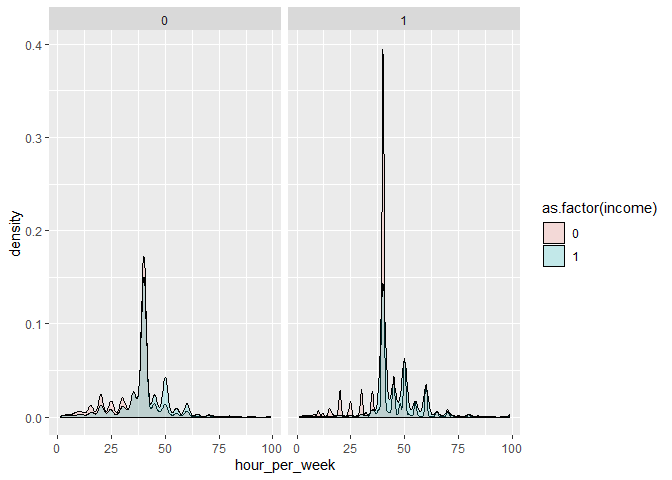

```r
ggplot(datosAdult, aes(hour_per_week, fill = as.factor(income)))+
  geom_density(alpha = 0.2) +
  facet_wrap(~sex)
```

Si observamos el mismo gráfico teniendo en cuenta el nivel educativo, podemos observar cómo las mujeres con menos estudios que ganan más de 50k suelen trabajar en torno a las horas estipuladas por ley (en torno a 40h semanales), mientras que las horas de los hombres están un poco más distribuidas.También se puede observar cómo a medida que el nivel educativo aumenta, las personas que ganan más de 50k tienden a trabajar más horas semanales.

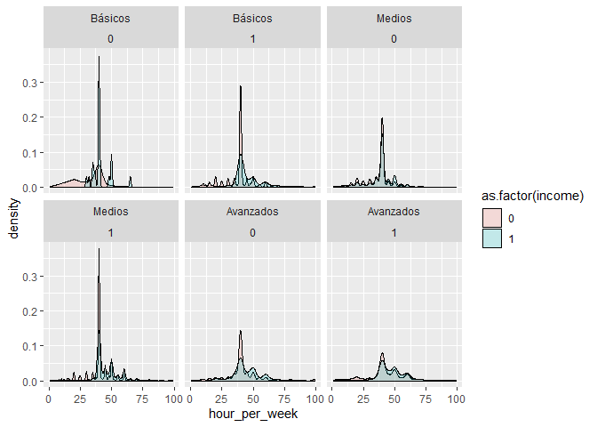

```r
ggplot(datosAdult, aes(hour_per_week, fill = as.factor(income)))+
  geom_density(alpha = 0.2) +
  facet_wrap(~education + sex)
```

También es interesante resaltar que las personas casadas (que anteriormente vimos que eran las que más veces pasaban de los 50k) son las que más veces trabajan en torno a 40h, mientras que para el resto de niveles es habitual ver personas que trabajan por encima de esta cantidad de horas (sobre todo personas que nunca se han casado y divorciadas).

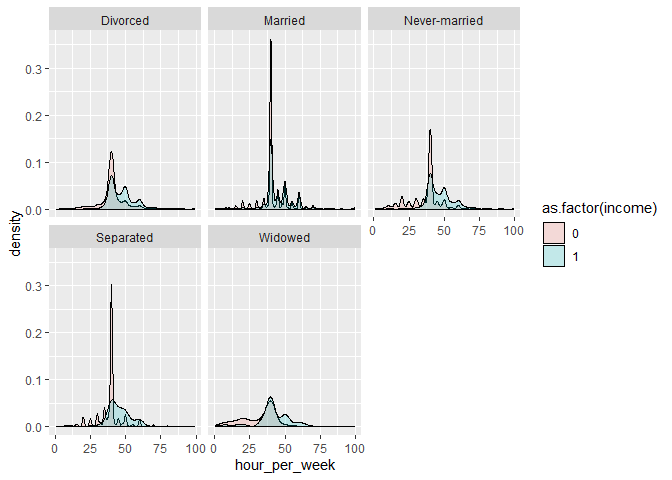

```r
ggplot(datosAdult, aes(hour_per_week, fill = as.factor(income)))+
  geom_density(alpha = 0.2) +
  facet_wrap(~marital_status)
```

```r
table(datosAdult$income, datosAdult$marital_status) %>% knitr::kable()
```

|  | Divorced | Married | Never-married | Separated | Widowed |
| --- | --- | --- | --- | --- | --- |
| 0 | 3980 | 8681 | 10192 | 959 | 908 |
| 1 | 463 | 6736 | 491 | 66 | 85 |

### 4.2.2 Ganancias y Pérdidas de Capital

En primer lugar, vamos a analizar si existe alguna relación entre las pérdidas y ganancias de capital.

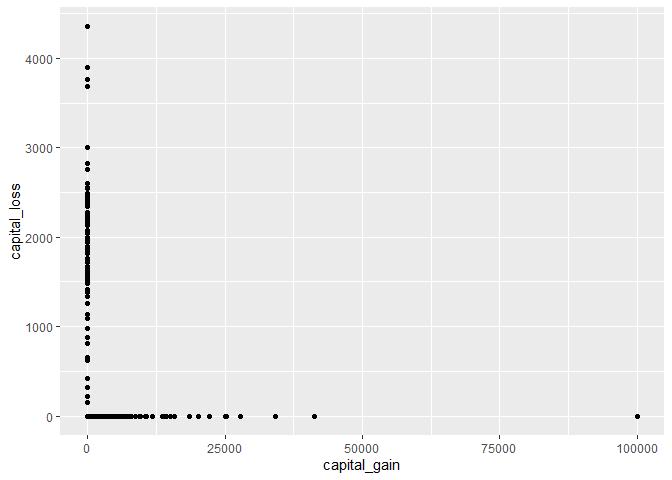

```r
ggplot(datosAdult) +
  geom_point(aes(capital_gain, capital_loss))
```

Se puede observar que (lógicamente) si una persona tiene una ganancia, no puede tener una pérdida y viceversa, de ahí que los datos estén exclusivamente en los dos ejes. Esto significa que podemos hacer una transformación para almacenar toda esta información en una única variable, que denominaremos ganancias:

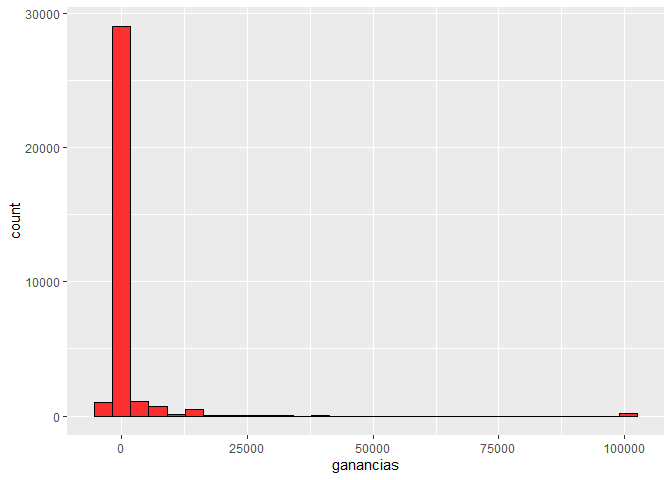

```r
datosAdult <- datosAdult %>% mutate(ganancias = capital_gain - capital_loss)

ggplot(datosAdult, aes(ganancias)) + geom_histogram(bins = 30, fill = "red", colour = "black", alpha = 0.8)
```

Como vemos, la gráfica está muy escorada a la izquierda, acumulando gran parte de los valores en 0 (ni ganancias ni pérdidas), en concreto, el 87% de las personas. Sin embargo, el 91% de las personas que tienen ganancias elevadas (>5000), ganan más de 50k, por lo que esta variable podría ser de utilidad para ayudar al algoritmo a predecir más valores >= 50k.

```r
datosAdult$ganancias %>% table() %>% prop.table() %>% .["0"] * 100
```

```
##        0
## 87.00593
```

```r
table(datosAdult[datosAdult$ganancias > 5000, 'income']) %>% prop.table() * 100
```

```
##
##         0         1
##  9.223301 90.776699
```

### 4.2.3 fnlwgt

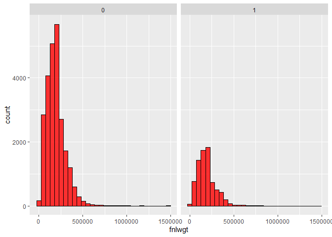

```r
ggplot(datosAdult, aes(fnlwgt)) +
  geom_histogram(bins = 30, fill = "red", colour = "black", alpha = 0.8) +
  facet_wrap(~income)
```

## 4.3 Missing Values

Para este dataset en particular, las únicas variables que tenían NA (?) eran workclass, occupation y native_country. Por razones que se han explicado anteriormente, no se consideró el tratamiento de estos valores para la variable native_country, puesto que no se utilizará en nuestro algoritmo. Vamos a utilizar las variables ‘workclass’ y ‘occupation’. En primer lugar, vamos a reemplazar los valores ‘?’ por NA:

```r
str_replace_all_na <- partial(str_replace_all, pattern = '\\?', replacement = NA_character_)

datosAdult <- datosAdult %>% modify_at(c('workclass', 'occupation'), str_replace_all_na)

sum(is.na(datosAdult))
```

```
## [1] 3679
```

En segundo lugar, yo siempre realizo una visualización de los missing values del dataset a través de la función ‘aggr’ de la librería ‘VIM’, que nos permite visualizar el número total de NA’s, cómo se relacionan entre ellos (en cuantas variables aparece para un mismo registro) y el número total de registros totalmente correctos:

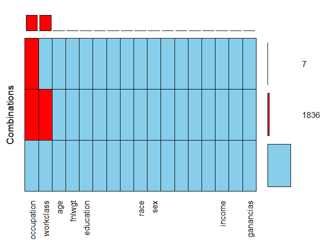

```
##
##  Variables sorted by number of missings:
##        Variable Count
##      occupation  1843
##       workclass  1836
##             age     0
##          fnlwgt     0
##       education     0
##   education_num     0
##  marital_status     0
##    relationship     0
##            race     0
##             sex     0
##    capital_gain     0
##    capital_loss     0
##   hour_per_week     0
##  native_country     0
##          income     0
##      age_breaks     0
##       ganancias     0
```

```r
aggr(datosAdult, prop = F, combined = T, numbers = T, sortVars = T, sortCombs = T)
```

Por último, puede hacerse una imputación de estos valores a partir de diversas técnicas, siendo las más utilizadas la media, moda, varianza o la aplicación de algoritmos como k-nearest neighbours o random forest. Para este paso, suelo elegir entre una de las siguientes dos opciones:

- Utilizar la función ‘mice’ del paquete que lleva el mismo nombre (infinidad de métodos para realizar la imputación) y permite la imputación de diversos métodos para cada una de las variables de una forma sencilla.
- Utilizar la librería de preprocesamiento ‘recipes’ y sus ‘step_%impute’ pasos para realizar la transformación deseada. Estos pasos serían los siguientes:

```r
str_extract_all(ls('package:recipes'), '^step_[a-z]+impute') %>% flatten_chr()
```

```
## [1] "step_bagimpute"    "step_knnimpute"    "step_lowerimpute"
## [4] "step_meanimpute"   "step_medianimpute" "step_modeimpute"
## [7] "step_rollimpute"
```

En este caso, se utilizará la segunda opción puesto que es mucho más rápida. Utilizaremos el algoritmo knn para predecir los valores faltantes (utiliza los valores más próximos (en términos de distancia) para calcular el valor faltante). También agruparemos los niveles de gobierno y autoempleado para no tener tantas variables dummy posteriormente en ‘workclass’:

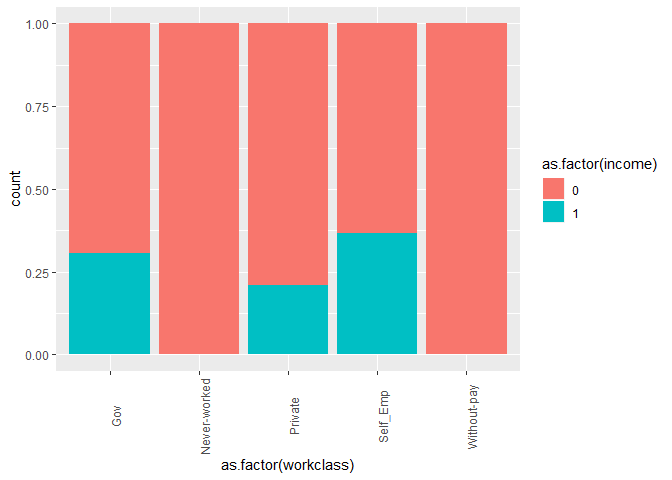

```r
datosAdult<- datosAdult %>% mutate(workclass = if_else(workclass %in% c('Self-emp-inc','Self-emp-not-inc'),
                                                       'Self_Emp',
                                                       str_replace_all(workclass, '[A-z]+-gov', 'Gov')))

datosAdult <- recipe(workclass + occupation  ~ ., datosAdult) %>% step_knnimpute(all_outcomes())  %>% prep() %>% juice()

ggplot(datosAdult, aes(as.factor(workclass), fill = as.factor(income))) +
         geom_bar(position = "fill") +
         theme(axis.text.x = element_text(angle = 90))
```

```r
levels(as.factor(datosAdult$workclass))
```

```
## [1] "Gov"          "Never-worked" "Private"      "Self_Emp"
## [5] "Without-pay"
```

```r
sum(is.na(datosAdult$workclass))
```

```
## [1] 0
```

## 4.4 Función de Preprocesamiento

Una de las librerías más importantes en R que permite hacer preprocesamiento de datos es ‘recipes’. Se ha creado una función basada en esta librería que facilita la aplicación de todas las funciones de preprocesamiento que contiene sobre variables numéricas o categóricas para variables que actúan como predictoras o cómo variables de salida. Esta función fue originalmente creada para una librería que he creado en la que se implementaba el algoritmo k-Nearest Neighbours ([knnClassifier library](https://github.com/AlbertoAlmuinha/knnClassifier/tree/master/R)):

```r
#' @title Preprocess
#' @description This function applies step functions of recipes package
#' @author Alberto Almuiña
#' @param formula Formula that will be evaluated in algorithm (for example: Species ~ .)
#' @param data Dataframe that will be modified
#' @param methods Steps functions of the recipes package to be applied. For example( c("step_center", "step_scale", "step_range"))
#' @param not_apply_on "nominal" or "numeric". The column type in which step functions will not be applied.
#' @param role "predictor" or "outcome". Outcome is the target variable and "Predictor" represent all the rest in "formula".
#' @return
#' Returns a data frame with all the changes applied.
#' @export
#' @examples
#' data<-preprocess(Species ~ ., iris, c("step_center", "step_scale", "step_range"), "numeric", "predictor")
#' data<-preprocess(Species ~ ., iris, c("step_dummy"), "nomianl", "outcome")


preprocess<-function(formula, data, methods = is.character(), not_apply_on = c("numeric", "nominal"),
                         role = c("predictor","outcome"), ...){

        methods<-match.arg(methods,
                           ls("package:recipes"),
                           several.ok = TRUE)

        not_apply_on<-match.arg(not_apply_on)

        role<-match.arg(role)

        recipes<-recipe(formula, data = data)

        step_functions<-map(methods, match.fun)

        data<-map(1:length(step_functions), function(x){

                prep<-recipes %>% step_functions[[x]](has_role(role), -has_type(not_apply_on)) %>% prep()

                bake(prep, data)

        }) %>% .[[length(step_functions)]] %>% as.data.frame()

        return(data)
}
```

Vamos a reescalar las variables numéricas para que todas se encuentren en el rango (0-1), seleccionar las variables que consideremos de interés para nuestro modelo (en base a lo que se fue comentando anteriormente), así como transformar en variables dummies aquellas variables categóricas que necesitan ser pasadas al algoritmo.

```r
datosAdult <- preprocess(income ~ .,
                         data = datosAdult,
                         methods = 'step_range',
                         not_apply_on = 'nominal',
                         role = 'predictor') %>%

              select(age, fnlwgt, education_num, marital_status, sex, hour_per_week, race, occupation,
                     ganancias, age_breaks, workclass, income) %>%


              preprocess(marital_status + race + occupation + workclass + age_breaks ~ .,
                         data = .,
                         methods = 'step_dummy',
                         not_apply_on = 'numeric',
                         role = 'outcome') %>%

              as.matrix() %>% as.data.frame()


glimpse(datosAdult)
```

```
## Observations: 32,561
## Variables: 34
## $ age                          <dbl> 0.30136986, 0.45205479, 0.2876712...
## $ fnlwgt                       <dbl> 0.04430190, 0.04823760, 0.1381134...
## $ education_num                <dbl> 0.8000000, 0.8000000, 0.5333333, ...
## $ sex                          <dbl> 1, 1, 1, 1, 0, 0, 0, 1, 0, 1, 1, ...
## $ hour_per_week                <dbl> 0.3979592, 0.1224490, 0.3979592, ...
## $ ganancias                    <dbl> 0.06257486, 0.04174213, 0.0417421...
## $ income                       <dbl> 0, 0, 0, 0, 0, 0, 0, 1, 1, 1, 1, ...
## $ marital_status_Married       <dbl> 0, 1, 0, 1, 1, 1, 1, 1, 0, 1, 1, ...
## $ marital_status_Never.married <dbl> 1, 0, 0, 0, 0, 0, 0, 0, 1, 0, 0, ...
## $ marital_status_Separated     <dbl> 0, 0, 0, 0, 0, 0, 0, 0, 0, 0, 0, ...
## $ marital_status_Widowed       <dbl> 0, 0, 0, 0, 0, 0, 0, 0, 0, 0, 0, ...
## $ race_Asian.Pac.Islander      <dbl> 0, 0, 0, 0, 0, 0, 0, 0, 0, 0, 0, ...
## $ race_Black                   <dbl> 0, 0, 0, 1, 1, 0, 1, 0, 0, 0, 1, ...
```

[output cut: 21 more lines]

## 4.5 Correlación

Una vez que tenemos el dataset para ser utilizado vamos a proceder a investigar si existe alguna correlación entre estas (con las variables numéricas que teníamos de inicio no tenía mucho sentido usarlo de primeras).

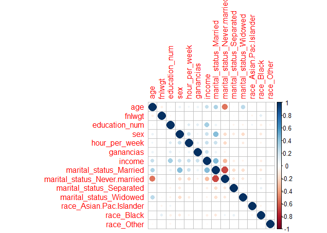

```r
corrplot(cor(datosAdult[,1:14]), method = 'circle')
```

Como vemos, las variables numéricas no están muy relacionadas entre si (las que sí lo están algo es porque son distintos niveles de variables dummies).

## 4.6 Regresión Logistica

Vamos a intentar predecir la variable categórica ‘income’ a partir del resto de variables seleccionadas en el paso anterior. Para ello, utilizaremos la librería creada por un servidor que implementa una regresión logistica para clasificación binaria. Puede consultarse más información sobre la librería en este enlace: LogisticRegression. En primer lugar, vamos a descargar e instalar el paquete desde el repositorio de GitHub. Para ello, se necesita tener instalado el paquete devtools.

```r
install_github("https://github.com/AlbertoAlmuinha/LogisticRegression", dependencies = FALSE)
library(LogisticRegression)
```

En primer lugar, vamos a divir nuestro dataset en train y test (Vamos a probar una configuración 80%-20%). Esto se hace para entrenar al modelo en el primer dataset y poder probarlo en el segundo. Para ello, usaremos la siguiente función:

```r
create_data_partition<-function(data, p_train){

        sampled_data<-partial(sample, size = round(p_train*dim(data)[1]))

        index<-do.call(sampled_data, list(1:dim(data)[1]))

        train<-data[index,]; test<-data[-index,]

        return(list(train = train, test = test))
}

c(train, test) %<-% create_data_partition(datosAdult, 0.8)
```

Ahora vamos a llamar a la función logistic_regression. Debemos tener en cuenta que se ha asignado un número pequeño de iteraciones (para encontrar los valores óptimos de theta con el algoritmo del descenso del gradiente para minimizar la función de coste) para que no lleve mucho tiempo. Por este motivo, también se utiliza un learning rate bastante elevado para que el algoritmo se pueda acercar al mínimo de la función en menos iteraciones. Como resultado mostramos una matriz de confusión, su gráfica y el valor que toma la función de coste para los parámetros seleccionados al terminar el número de iteraciones.

```r
reglog1 <- logistic_regression(train = train,
                               test = test,
                               target = 7,
                               threshold = 0.2,
                               max_iter = 1000,
                               lr = 3.5)

reglog1$conf_matrix
```

```
## Confusion Matrix and Statistics
##
##           Reference
## Prediction     0     1
##          0 18279  2729
##          1  1479  3562
##
##                Accuracy : 0.8385
##                  95% CI : (0.8339, 0.8429)
##     No Information Rate : 0.7585
##     P-Value [Acc > NIR] : < 2.2e-16
##
##                   Kappa : 0.527
##
##  Mcnemar's Test P-Value : < 2.2e-16
##
##             Sensitivity : 0.9251
##             Specificity : 0.5662
##          Pos Pred Value : 0.8701
##          Neg Pred Value : 0.7066
##              Prevalence : 0.7585
##          Detection Rate : 0.7017
##    Detection Prevalence : 0.8065
##       Balanced Accuracy : 0.7457
##
##        'Positive' Class : 0
##
```

```r
reglog1$optim_theta$cost_history[1000]
```

```
## [1] 0.3424817
```

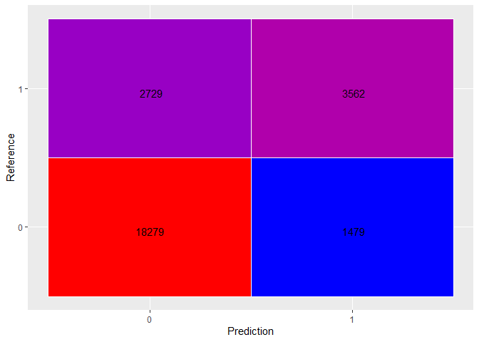

```r
reglog1$conf_matrix_plot
```

Como hemos ido comentando, vamos a comprobar como se comporta la regresión logística al no usar la variable ‘ganancias’ en nuestra predicción:

```r
logreg2 <- logistic_regression(train = train[, -6],
                               test = test[,-6],
                               target = 6,
                               threshold = 0.2,
                               max_iter = 1000,
                               lr = 3.5)

logreg2$conf_matrix
```

```
## Confusion Matrix and Statistics
##
##           Reference
## Prediction     0     1
##          0 17761  2443
##          1  1997  3848
##
##                Accuracy : 0.8296
##                  95% CI : (0.8249, 0.8341)
##     No Information Rate : 0.7585
##     P-Value [Acc > NIR] : < 2.2e-16
##
##                   Kappa : 0.5232
##
##  Mcnemar's Test P-Value : 2.417e-11
##
##             Sensitivity : 0.8989
##             Specificity : 0.6117
##          Pos Pred Value : 0.8791
##          Neg Pred Value : 0.6583
##              Prevalence : 0.7585
##          Detection Rate : 0.6818
##    Detection Prevalence : 0.7756
##       Balanced Accuracy : 0.7553
##
##        'Positive' Class : 0
##
```

```r
logreg2$optim_theta$cost_history[1000]
```

```
## [1] 0.359323
```

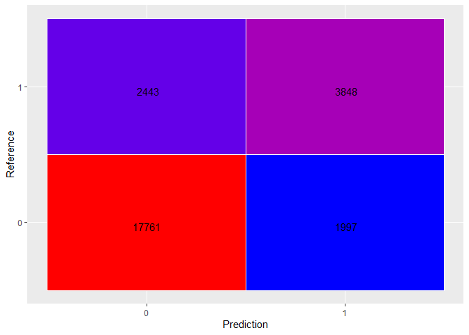

```r
logreg2$conf_matrix_plot
```

```r
logreg3 <- logistic_regression(train = train,
                               test = test,
                               target = 7,
                               threshold = 0.2,
                               max_iter = 1000,
                               lr = 3.5,
                               regu_method = "ridge",
                               regu_factor = 100)

logreg3$conf_matrix
```

```
## Confusion Matrix and Statistics
##
##           Reference
## Prediction     0     1
##          0 17719  2334
##          1  2039  3957
##
##                Accuracy : 0.8321
##                  95% CI : (0.8275, 0.8366)
##     No Information Rate : 0.7585
##     P-Value [Acc > NIR] : < 2.2e-16
##
##                   Kappa : 0.5343
##
##  Mcnemar's Test P-Value : 8.753e-06
##
##             Sensitivity : 0.8968
##             Specificity : 0.6290
##          Pos Pred Value : 0.8836
##          Neg Pred Value : 0.6599
##              Prevalence : 0.7585
##          Detection Rate : 0.6802
##    Detection Prevalence : 0.7698
##       Balanced Accuracy : 0.7629
##
##        'Positive' Class : 0
##
```

```r
logreg3$optim_theta$cost_history[1000]
```

```
## [1] 33.87878
```

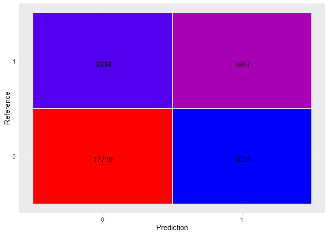

```r
logreg3$conf_matrix_plot
```

Se puede observar cómo ahora el algoritmo clasifica mejor más valores ‘1’, mejorando el specificity a costa del accuracy, como era de esperar. El siguiente paso sería el hyper-paramater tuning, que vendría a ser localizar los valores óptimos de lr, max_iter y ridge_factor para obtener los mejores resultados posibles.

### 4.6.1 PCA: Análisis de Componentes Principales

Como último paso, vamos a realizar un análisis de componentes principales para reducir la dimensionalidad de nuestro dataset. Esta técnica consiste en realizar cambios de base de nuestros datos para rotar los ejes de las N dimensiones para poder reducir el número de variables que se necesitan. Una forma sencilla de verlo es imaginar un par de variables que representan una recta creciente perfecta en un eje de coordenadas (x,y). Si se realiza una rotación de los ejes, podemos seleccionar la rotación que nos deje uno de los ejes sobre la propia recta, lo que significa que ahora este eje contendrá toda la información, pudiendo descartarse el otro. El objetivo es mantener las componentes principales que nos permiten explicar una varianza que nosotros consideremos suficiente para el problema que estamos a resolver.

```r
pca <- princomp(datosAdult[, -7])

summary(pca)
```

```
## Importance of components:
##                           Comp.1    Comp.2     Comp.3     Comp.4
## Standard deviation     0.7258840 0.5154455 0.49111988 0.45085821
## Proportion of Variance 0.2084703 0.1051176 0.09542998 0.08042476
## Cumulative Proportion  0.2084703 0.3135879 0.40901786 0.48944261
##                            Comp.5     Comp.6     Comp.7     Comp.8
## Standard deviation     0.42961546 0.36511855 0.35618522 0.34823121
## Proportion of Variance 0.07302467 0.05274455 0.05019513 0.04797833
## Cumulative Proportion  0.56246728 0.61521183 0.66540696 0.71338529
##                            Comp.9    Comp.10    Comp.11    Comp.12
## Standard deviation     0.32330222 0.30394505 0.27440519 0.23939251
## Proportion of Variance 0.04135492 0.03655106 0.02979164 0.02267415
## Cumulative Proportion  0.75474021 0.79129127 0.82108291 0.84375706
##                           Comp.13   Comp.14    Comp.15    Comp.16
## Standard deviation     0.23203879 0.2183521 0.21431395 0.20997617
## Proportion of Variance 0.02130252 0.0188636 0.01817233 0.01744415
## Cumulative Proportion  0.86505958 0.8839232 0.90209551 0.91953966
##                           Comp.17    Comp.18    Comp.19     Comp.20
## Standard deviation     0.18702356 0.17208492 0.16789436 0.141304947
## Proportion of Variance 0.01383893 0.01171643 0.01115275 0.007899953
## Cumulative Proportion  0.93337859 0.94509502 0.95624777 0.964147724
##                            Comp.21     Comp.22     Comp.23    Comp.24
## Standard deviation     0.136354965 0.131508712 0.113466330 0.10550791
## Proportion of Variance 0.007356169 0.006842564 0.005093822 0.00440433
## Cumulative Proportion  0.971503893 0.978346456 0.983440279 0.98784461
##                            Comp.25     Comp.26     Comp.27     Comp.28
## Standard deviation     0.091941745 0.071296114 0.070305439 0.068153032
## Proportion of Variance 0.003344531 0.002011136 0.001955634 0.001837723
## Cumulative Proportion  0.991189140 0.993200277 0.995155911 0.996993634
##                            Comp.29      Comp.30      Comp.31      Comp.32
## Standard deviation     0.067498072 0.0461140025 0.0206609144 0.0165805932
## Proportion of Variance 0.001802572 0.0008413475 0.0001688919 0.0001087702
## Cumulative Proportion  0.998796206 0.9996375535 0.9998064454 0.9999152156
##                             Comp.33
## Standard deviation     1.463872e-02
## Proportion of Variance 8.478442e-05
## Cumulative Proportion  1.000000e+00
```

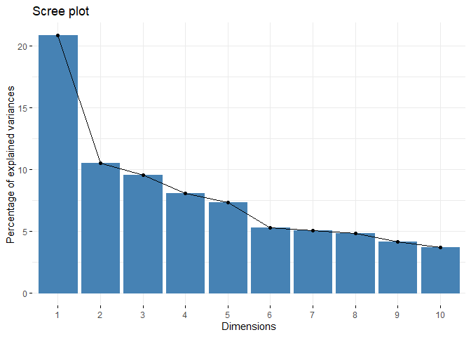

```r
fviz_screeplot(pca)
```

Podemos ver a través de ‘Cumulative Proportion’ la cantidad de información que explica esa componente más las n-1 anteriores. En este caso, vamos a coger las 23 principales componentes, que explican un 98,3% de la varianza de los datos y también los vamos a rescalar entre 0 y 1.

```r
pca <- pca$scores[,1:23] %>% as.data.frame() %>%

          mutate(income = datosAdult$income) %>%

          recipe(income ~ .) %>%

          step_range(all_predictors()) %>%

          prep() %>%

          juice() %>%

          as.data.frame()

str(pca)
```

```
## 'data.frame':    32561 obs. of  24 variables:
##  $ Comp.1 : num  0.469 0.978 0.582 0.756 0.5 ...
##  $ Comp.2 : num  0.405 0.501 0.321 0.253 0.379 ...
##  $ Comp.3 : num  0.525 0.662 0.174 0.163 0.402 ...
##  $ Comp.4 : num  0.112 0.293 0.333 0.556 0.767 ...
##  $ Comp.5 : num  0.655 0.704 0.738 0.157 0.37 ...
##  $ Comp.6 : num  0.5896 0.8589 0.6009 0.5061 0.0467 ...
##  $ Comp.7 : num  0.456 0.21 0.479 0.379 0.355 ...
##  $ Comp.8 : num  0.692 0.758 0.701 0.595 0.652 ...
##  $ Comp.9 : num  0.501 0.511 0.527 0.518 0.631 ...
##  $ Comp.10: num  0.596 0.389 0.726 0.507 0.159 ...
##  $ Comp.11: num  0.555 0.665 0.479 0.492 0.662 ...
##  $ Comp.12: num  0.485 0.609 0.335 0.368 0.505 ...
##  $ Comp.13: num  0.693 0.554 0.383 0.567 0.456 ...
##  $ Comp.14: num  0.833 0.422 0.54 0.585 0.42 ...
##  $ Comp.15: num  0.421 0.478 0.888 0.962 0.451 ...
##  $ Comp.16: num  0.3399 0.2034 0.3202 0.14 0.0301 ...
##  $ Comp.17: num  0.582 0.71 0.867 0.863 0.601 ...
##  $ Comp.18: num  0.399 0.489 0.422 0.421 0.418 ...
##  $ Comp.19: num  0.529 0.473 0.464 0.483 0.426 ...
##  $ Comp.20: num  0.284 0.326 0.324 0.269 0.329 ...
##  $ Comp.21: num  0.638 0.525 0.797 0.609 0.622 ...
##  $ Comp.22: num  0.723 0.575 0.547 0.56 0.587 ...
##  $ Comp.23: num  0.343 0.113 0.371 0.408 0.403 ...
##  $ income : num  0 0 0 0 0 0 0 1 1 1 ...
```

```r
c(pca_train, pca_test) %<-% create_data_partition(pca, 0.8)

pca_reg_log <- logistic_regression(train = pca_train,
                               test = pca_test,
                               target = 24,
                               threshold = 0.2,
                               max_iter = 1000,
                               lr = 3.5,
                               regu_factor = 100)

pca_reg_log$conf_matrix
```

```
## Confusion Matrix and Statistics
##
##           Reference
## Prediction     0     1
##          0 17554  2292
##          1  2211  3992
##
##                Accuracy : 0.8271
##                  95% CI : (0.8225, 0.8317)
##     No Information Rate : 0.7588
##     P-Value [Acc > NIR] : <2e-16
##
##                   Kappa : 0.5257
##
##  Mcnemar's Test P-Value : 0.2332
##
##             Sensitivity : 0.8881
##             Specificity : 0.6353
##          Pos Pred Value : 0.8845
##          Neg Pred Value : 0.6436
##              Prevalence : 0.7588
##          Detection Rate : 0.6739
##    Detection Prevalence : 0.7619
##       Balanced Accuracy : 0.7617
##
##        'Positive' Class : 0
##
```

```r
pca_reg_log$optim_theta$cost_history[1000]
```

```
## [1] 46.65591
```

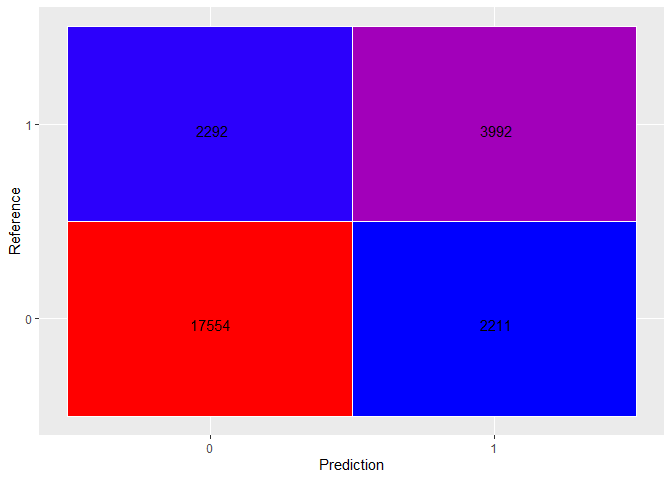

```r
pca_reg_log$conf_matrix_plot
```

Se puede observar que en este caso obtenemos unos resultados muy similares que en las predicciones anteriores pero con 10 dimensiones menos. Es importante resaltar que este método es más adecuado cuando se tiene un volumen mayor de registros, donde el coste computacional es un factor muy importante. Los resultados pueden variar un poco cada vez que se lanza, puesto que la función ‘create_data_partition’ separa en train-test datasets de forma aleatoria, por lo que depende de los registros que caigan en cada uno de ellos.

## 4.7 Conclusiones

**En cuánto a las variables:**

- Cuánto mayor es el nivel educativo de las personas, mayor es el número de personas que ganan más de 50k. Además, hay dos variables que nos aportan exactamente la misma información, por lo que se prescinde de ‘education’ y se mantiene la variable numérica (más fácil de procesar para el algoritmo).
- Hay más hombres que mujeres que ganan más de 50k.
- Pueden observarse importantes diferencias de ganancias entre las diferentes profesiones y también entre los distintos sectores laborales (aunque estas diferencias son menores cuando se agrupan los niveles en Gobierno y Auto-Empleado).
- Las personas menores de 30 años tienen unos ingresos mucho menores debido posiblemente a que aún están empezando su carrera profesional. Sin embargo, los dos siguientes niveles (de 30 a 55 y de 55 a 100 años) son muy similares.
- Casi un 50% de los casados ganan más de 50k, estando todos los siguientes niveles en torno al 10%. La misma información puede obtenerse al analizar la variable ‘relationship’, donde casi el 50% de los maridos y mujeres supera el umbral de los 50k. Por este motivo, al aportar casi la misma información, se descarta la variable ‘relationship’.
- En cuánto a la raza, el dataset está muy desbalanceado en favor de la clase ‘White’. Aunque pueden apreciarse ciertas diferencias entre las clases, habría que intentar igualar más las clases.
- El 89% de las personas son de Estados Unidos, mientras que el 11% restante está muy dividido en múltiples clases. Esta variable no es de utilidad para la predicción del ‘income’ (se han hecho pruebas incluyéndola y el resultado siempre disminuye, añadiendo ruido al modelo).
- Puede observarse cómo las mujeres que ganan más de 50k trabajan más horas a la semana, al igual que sucede con los hombres (aunque la diferencia no es tan notable respecto a los que no lo ganan). Por otro lado, si se analizan las horas trabajadas por sexo y nivel educativo, también se observa como para las personas con estudios avanzados se trabajan más horas.
- A partir de las ganancias y pérdidas de capital, puede obtenerse la variable ‘ganancias’, que es la resta de ambas. A pesar de que el 87% de las personas no tienen ninguna ganancia, esta variable es importante para el modelo porque ayuda a distinguir a las personas que sí ganan más de 50k.

**En cuánto al preprocesamiento de los datos:**

- Se han realizado agrupaciones de niveles para las variables ‘workclass’, ‘education’ y ‘marital_status’. Por otro lado, se ha agrupado la edad y el nivel educativo.
- Se han convertido los valores ‘?’ en NA tanto para workclass como para occupation. Posteriormente, se han imputado estos valores mediante el algoritmo k-Nearest Neighbour, buscando la información entre los vecinos más próximos.
- Se han reescalado las variables numéricas que se han utilizado en la predicción entre 0 y 1 debido a las grandes diferencias entre sus valores.
- Las variables categóricas se han transformado en variables ‘dummy’ para poder ser procesadas por el algoritmo.
- Variables con muy poca correlación entre ellas (exceptuando los distintos niveles de las variables dummy entre ellas)

**En cuánto al algoritmo usado para predecir:**

- Se ha utilizado la función logistic_regression de la librería LogisticRegression creada por el autor de este trabajo, que permite la clasificación binaria.
- Se han obtenido unos resultados muy decentes (teniendo en cuenta que no se ha hecho ningún tipo de hyper-parameter tuning). El principal problema encontrado está en el desbalanceamiento de la clase ‘income’ y que la regresión tiende a predecir ‘0’, por lo que obtiene unos valores para la ‘specificity’ bastante bajos.
- Para intentar solucionar el problema anterior, se utiliza la regularización Ridge para penalizar al algoritmo, consiguiendo aumentarse el número de clasificaciones ‘1’ hechas correctamente (aumentando la specificity).
- También se comprueba que la variable ‘ganancias’ creada mejora en torno a 1% el resultado.
- Finalmente, se ha realizado un análisis de componentes principales para descartar 10 dimensiones y obtener un resultado bastante similar al inicial (técnica importante cuando el coste computacional es muy importante). Se utilizan las primeras 23 componentes que explican el 98% de la varianza de los datos.